# A4: Jail Population Report

Maggie Liang

2022-11-20

## Abstract

This report covers some data analysis of US prison population data from 1970 to 2018. For example, the data changes from 1970 to 2018 and after 2000, the total number and average of the prison population in the United States, the gender distribution in prisons, and so on.

## Introduction

Safety is usually one of the survival criteria that cannot be ignored for ordinary people, and the crime situation can represent the safety level of an area on the one hand. For the degree of safety, we usually use the number of crimes in an area as a measure, and at the same time, the statistics of the prison population are also very representative. However, prisons are also one of the places with the worst racism in the United States. The incarceration data we obtained from the Vera Institute includes prison populations of different genders and prison populations of different races. This data can effectively allow us to analyze the trends of gender and race in the prison population, how these trends are related to racism, and even whether there is unfairness because of racism. To answer and summarize these questions, we will provide evidence through data summary and analysis, and also visualize the data to help people discover the relationship and results between the data more simply and clearly. In this data analysis report, various data analysis and visualization skills to expose patterns of inequality will be used.

## Data Summary

#### What is the total number of people in the prison of each State after Year 2000?

```
## # A tibble: 51 × 2
##    state  total
##    <chr>  <dbl>
##  1 CT        0
##  2 DE        0
##  3 HI        0
##  4 RI        0
##  5 VT        0
##  6 AK     1370.
##  7 ND    21362.
##  8 WY    28443.
##  9 SD    30360.
## 10 ME    31256.
## # … with 41 more rows
```

#### What is the average number of each category after Year 2000?

```
##       yfips year     fips total_pop total_pop_15to64 female_pop_15to64
## 1 200930367 2009 30367.47  97398.66         64877.91          32555.69
##   male_pop_15to64 aapi_pop_15to64 black_pop_15to64 latinx_pop_15to64
## 1        32322.22        3605.647         8358.417          10182.43
##   native_pop_15to64 white_pop_15to64 commuting_zone metro_area land_area
## 1          546.9051         42184.51       277.4955   29630.24   1125.57
##   total_jail_pop female_jail_pop male_jail_pop female_adult_jail_pop
## 1       247.4231        31.68435      214.9848               31.5198
##   female_juvenile_jail_pop male_adult_jail_pop male_juvenile_jail_pop
## 1                0.1702688             213.102               1.883473
##   aapi_jail_pop black_jail_pop latinx_jail_pop native_jail_pop white_jail_pop
## 1      2.544404       91.90147         39.5224        3.270875       109.9831
##   other_race_jail_pop total_jail_pretrial total_jail_from_prison
## 1            3.191321            149.1623               33.86222
##   total_jail_from_other_jail total_jail_from_fed total_jail_from_bia
## 1                   10.76956             15.2049          0.08365769
##   total_jail_from_bop total_jail_from_ice total_jail_from_marshals
## 1            0.881854            5.296571                 8.549827
##   total_jail_from_other_fed jail_rated_capacity private_jail_flag
## 1                 0.5785507            283.0467        0.01138491
##   regional_jail_flag total_jail_adm total_jail_dis total_jail_pop_dcrp
## 1          0.1424188       4119.129       4099.309            223.8021
##   female_jail_pop_dcrp male_jail_pop_dcrp total_jail_adm_dcrp
## 1             28.17593           197.7063            3737.771
##   female_jail_adm_dcrp male_jail_adm_dcrp total_prison_pop female_prison_pop
## 1             699.5655           3037.931          456.861          40.49438
##   male_prison_pop aapi_prison_pop black_prison_pop latinx_prison_pop
## 1         538.981        8.644409         301.7175          144.4992
##   native_prison_pop other_race_prison_pop white_prison_pop
## 1          13.31469              13.89757         217.2391
##   aapi_female_prison_pop aapi_male_prison_pop black_female_prison_pop
## 1              0.5078325             6.674036                15.96927
##   black_male_prison_pop latinx_female_prison_pop latinx_male_prison_pop
## 1              295.3539                  7.51767               152.8511
##   native_female_prison_pop native_male_prison_pop other_race_female_prison_pop
## 1                 1.818308               13.28307                    0.9007634
##   other_race_male_prison_pop white_female_prison_pop white_male_prison_pop
## 1                   15.74707                22.91635              210.8513
##   total_prison_adm female_prison_adm male_prison_adm aapi_prison_adm
## 1         218.9671          33.31221        252.3106        3.436661
```

[output cut: 15 more lines]

```
## 1            3725.009             1157.625             1389.674
##   white_jail_pop_rate total_jail_adm_rate total_jail_pretrial_rate
## 1            389.1362            8577.994                 272.3551
##   total_prison_pop_rate female_prison_pop_rate male_prison_pop_rate
## 1              663.2878               126.9343             1279.196
##   aapi_prison_pop_rate black_prison_pop_rate latinx_prison_pop_rate
## 1             37.43026              2985.521               999.8109
##   native_prison_pop_rate white_prison_pop_rate total_prison_adm_rate
## 1               826.0017              517.3195              354.9747
##   female_prison_adm_rate male_prison_adm_rate aapi_prison_adm_rate
## 1               114.0767             657.2819             16.97597
##   black_prison_adm_rate latinx_prison_adm_rate native_prison_adm_rate
## 1              1398.706               422.1086               477.8385
##   white_prison_adm_rate
## 1              297.1086
```

#### Which year has the highest number of people in jail, which year has the lowest?

```
## # A tibble: 1 × 2
##    year   total
##   <int>   <dbl>
## 1  2008 778201.
```

```
## # A tibble: 1 × 2
##    year   total
##   <int>   <dbl>
## 1  1971 155679.
```

From the above three questions, we can get the total prison population of each state in the United States after 2000. Among them, the five states of CT, DE, HI, RI, and VT have a prison population of 0 after 2000. We also calculated the average value of each variable after 2000. From the results, it can be concluded that the average number of prison populations for blacks is 91.9, and the average number of prison populations for whites is 109.9. Finally, we calculated in which year the prison population had the largest and smallest values. The result we got is that there was a largest population of 778200 in 2008 and a smallest population of 155679 in 1971.

## Growth of the U.S. Prison Population

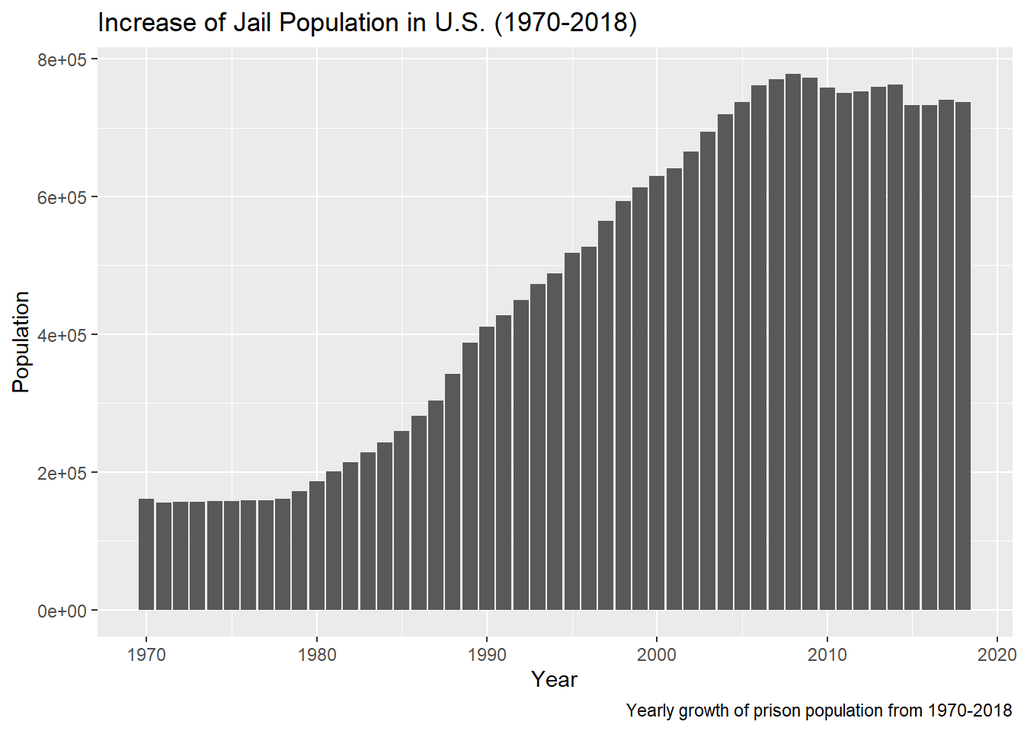

From the bar chart, we can see that the jail population did not change much between 1970 and 1980, increased rapidly between 1980 and 2008, and began to decline after reaching its peak in 2008. What causes fluctuations in jail population? Are these fluctuations related to economic and technological growth trends?

## Growth of Prison Population by State

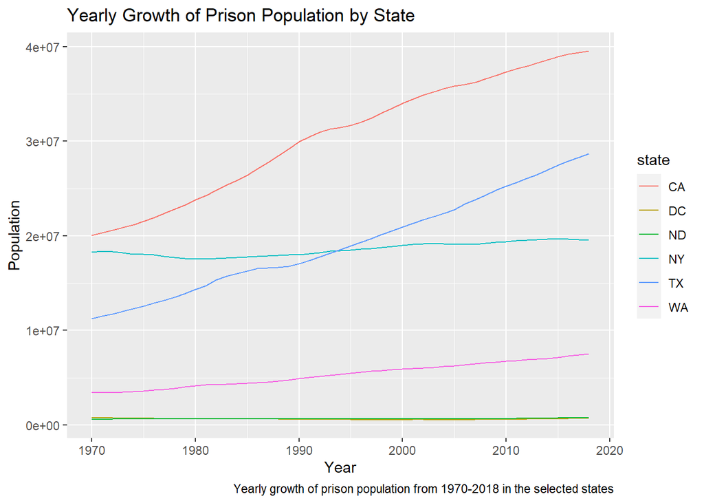

From the line plot, we can see that the jail population in most states has a small annual growth rate, but the jail population in California and Texas has a significant annual growth. In the graph, one state from the east, west, north and south of the United States is selected to observe the trend. Trends in the jail population should have a lot to do with population numbers and trends in population mobility.

## Gender Compaison Visualization by Year

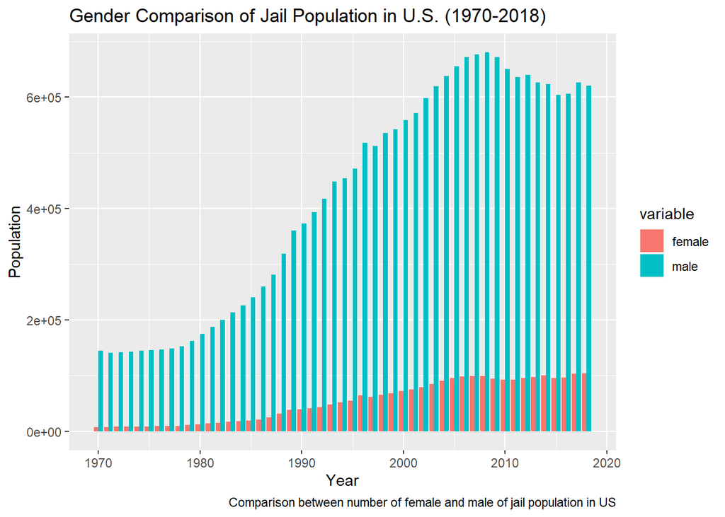

What are the relationships and trends of different genders in the jail population? From the bar chart we can see that the number of men in the jail population is far greater than the number of women. Between 1980 and 2008 there was a significant increase in the male jail population while the female jail population grew slowly. However, since 2010, the male jail population has declined significantly while the female jail population has not changed much. But overall the male and female jail populations are growing or shrinking in tandem.

## Average Jail Population Map visualization by State

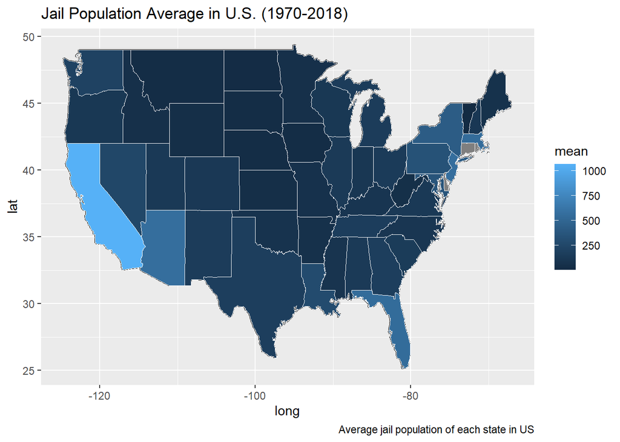

How is the average jail population distributed on the geographic map? In the geographic map we use shades of color for different states to represent differences in the average jail population. We can clearly find that California has the lightest color which indicate the largest average jail population, and the jail population in the central states is much less than that the jail population in the eastern and western coastal states.